# Step by step example for Bayesian inference: MH MCMC solution

Fabienne Krauer

2022-09-05

```r
library(deSolve)
library(ggplot2)
set.seed(42)
```

## The question

Let’s assume we have a map of the world, and we want to figure out what proportion is covered by water.

## The data

Do answer the question, we close our eyes and randomly point at the map and write down whether it is Water (0) or Land (1). We get the following data:

```r
data = c(0,0,1,0,1,1,0,1,1,1,0,0,1,0,0,0,1,0,1,0,1,0,0,1,0,0,1,1,0,0,1,0,1,0,0,1,0,1,0,0,0,0,0,0,1,0,1,1,0,1,1,1,0,0,1,0,0,0,1,0,1,0,1,0,0,1,0,0,1,1,0,0,1,0,1,0,0,1,0,1,0,0,0,0)
```

## The likelihood

The likelihood function that describes the process of multiple Bernoulli events (0 or 1) is a Binomial likelihood. The parametrization requires to input the number of trials (=data points) and the number of successes (=n of data points with the value of interest (water)):

```r
loglik <- function(data, p) {

  trials = length(data)
  success = length(data[data==0])
  ll = dbinom(success, trials, p, log=TRUE)

  return(ll)

}
```

# Set up the prior function:

```r
prior_beta <- function(p) {
    priordens <- dbeta(p, shape1 = 150, shape2 = 30, log=TRUE)
    return(priordens)
}

prior_unif <- function(p){
    priordens <- dunif(p, min=0, max=1, log=TRUE)
    return(priordens)
}
```

# Set up the posterior function (“target”)

```r
# Posterior function
posterior <- function(data, p){

   return (loglik(data, p) + prior_beta(p))
}
```

# The MH MCMC

```r
MH_MCMC <- function(theta_init, proposal_sd, data, iterations){

    # Set up an empty matrix to hold the value of the proposed theta and the iteration
    chain = matrix(NA, nrow=iterations+1, ncol=2)

    # The first sample is the initial values chosen
    theta_current <- theta_init

    # evaluate the posterior for the current initial values of p
    posterior_current <- posterior(data, theta_current)

    # Write the results to the chain array:
    chain[1,1] = theta_current
    chain[1,2] = 0

    # run MCMC for every iteration:
    for (i in seq_len(iterations)) {

      # 2. draw a new theta from the (Gaussian=Normal) proposal distribution
      # with the mean being the current theta
      theta_proposed <- rnorm(n = length(theta_current),
                              mean = theta_current,
                              sd = proposal_sd)

    # The next two lines are only required if your theta are proportions:
    # The normal proposal can lead to theta being proposed outside its domain (0,1 for probabilites).
    # We therefore need to rescale the proposed theta if this happens:
      if(theta_proposed < 0) theta_proposed <- abs(theta_proposed)
      if(theta_proposed > 1) theta_proposed <- 2-theta_proposed

      # 3. evaluate the posterior at the proposed theta
      posterior_proposed <- posterior(data, theta_proposed)

      # 4. Compute the acceptance probability
      # This is a substraction, because we work on a log-scale
      # substraction on log scale == ratio on normal scale
      ratio <- exp(posterior_proposed - posterior_current)
      r = min(1, ratio) # this ensures that you always accept the proposed theta when it improves the posterior

      # 5. Draw random number number between 0 and 1 and establish whether to         accept the sample or not. If the random number is smaller than the              acceptance probability, then accept the proposal:
      u <- runif(1)

      if (u <= r) {

        # change the current value of theta to the proposed theta
        theta_current <- theta_proposed

        # updated the current value of the posterior
        posterior_curent <- posterior_proposed
        # Write the results to the array

      }

    chain[i+1,1] <- theta_current
    chain[i+1,2] <- i

    #message("iteration: ", i)


    }

    chain <- data.frame(chain)
    colnames(chain) <- c("theta", "iter")
    return(chain)
}
```

We can run this MCMC, but the mixing is very poor, because there is no adaptation of the proposal. The purpose is mainly to demonstrate how the MH-MCMC is coded in practice. In reality, you would probably use a designated MCMC package, which is optimized for performance.

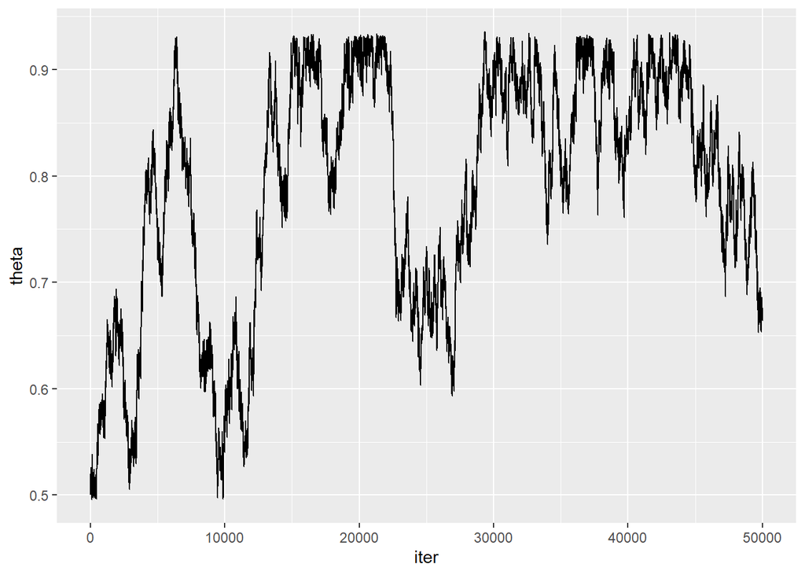

```r
n_samples <- 50000 # number of draws
proposal_sd <- 0.003
theta_init <- 0.5
chain <- MH_MCMC(theta_init, proposal_sd, data, n_samples)
ggplot(chain) + geom_line(aes(x=iter, y=theta))
```

## Disclaimer

This example is based on Richard McElreath’s “globe tossing” example in “Statistical Rethinking” (3rd edition), see page 45.